# practical-03(B)html

```python
import os
import pandas as pd
import matplotlib.pyplot as plt
import seaborn as sns
import numpy as np

from sklearn.impute import KNNImputer
from sklearn.preprocessing import Normalizer, PolynomialFeatures, StandardScaler, OneHotEncoder, LabelEncoder, MinMaxScaler
from sklearn.model_selection import train_test_split
from sklearn.linear_model import LinearRegression
from sklearn.metrics import mean_squared_error, r2_score, accuracy_score, adjusted_rand_score, silhouette_score
from sklearn.decomposition import PCA
from sklearn.neighbors import KNeighborsClassifier
from sklearn.tree import DecisionTreeClassifier, plot_tree
from sklearn.cluster import KMeans, DBSCAN
```

```python
""" Read the data file into a Pandas data frame. Inspect Data"""

cwd = os.getcwd()
print("Current Working Directory:", cwd)

df1 = pd.read_csv("question_1.csv")

df1.head(10)
```

```
Current Working Directory: c:\Users\35385\Desktop\CS_Autumn2024\DataMining\Tom_Gibson-p3
```

|  | x | y | org_cluster |
| --- | --- | --- | --- |
| 0 | 10.9 | 12.6 | 2 |
| 1 | 2.3 | 8.4 | 1 |
| 2 | 8.4 | 12.6 | 1 |
| 3 | 12.1 | 16.2 | 2 |
| 4 | 7.3 | 8.9 | 1 |
| 5 | 23.4 | 11.3 | 2 |
| 6 | 19.7 | 18.5 | 2 |
| 7 | 17.1 | 17.2 | 2 |
| 8 | 3.2 | 3.4 | 1 |
| 9 | 1.3 | 22.8 | 0 |

```python
df1.tail(10)
```

|  | x | y | org_cluster |
| --- | --- | --- | --- |
| 30 | 1.1 | 22.1 | 0 |
| 31 | 4.0 | 7.1 | 1 |
| 32 | 10.1 | 11.5 | 1 |
| 33 | 3.5 | 11.6 | 1 |
| 34 | 9.3 | 12.5 | 1 |
| 35 | 5.5 | 12.4 | 2 |
| 36 | 21.1 | 22.5 | 2 |
| 37 | 6.2 | 21.5 | 2 |
| 38 | 20.4 | 13.5 | 2 |
| 39 | 11.0 | 15.0 | 0 |

```python
df1.shape
```

```
(40, 3)
```

```python
df1.info()
```

```
<class 'pandas.core.frame.DataFrame'>
RangeIndex: 40 entries, 0 to 39
Data columns (total 3 columns):
 #   Column       Non-Null Count  Dtype
---  ------       --------------  -----
 0   x            40 non-null     float64
 1   y            40 non-null     float64
 2   org_cluster  40 non-null     int64
dtypes: float64(2), int64(1)
memory usage: 1.1 KB
```

Question 1: K-Means Clustering:

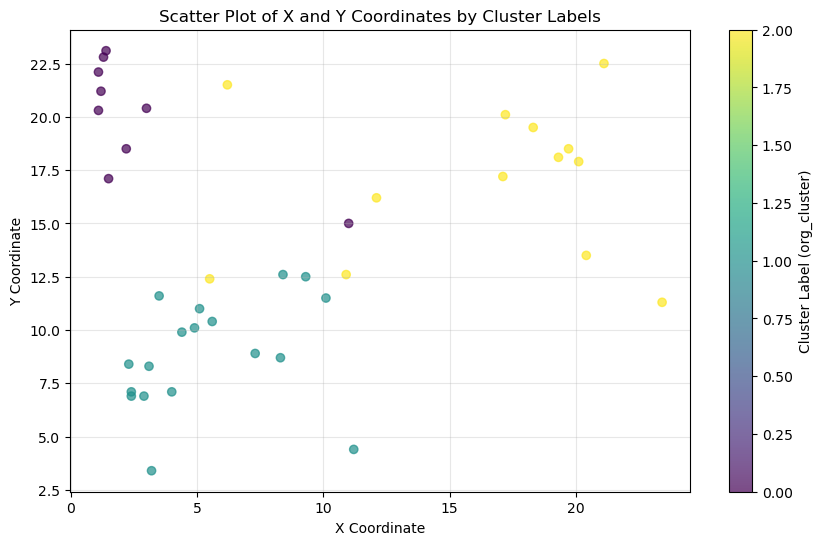

```python
""" 1.1) Visualise the attributes/coordinates (x, and y) in a scatter plot with different colours
according to cluster labels (org_cluster)."""

plt.figure(figsize=(10, 6))
scatter = plt.scatter(df1['x'], df1['y'], c=df1['org_cluster'], cmap='viridis', alpha=0.7)
plt.colorbar(scatter, label='Cluster Label (org_cluster)')
plt.xlabel('X Coordinate')
plt.ylabel('Y Coordinate')
plt.title('Scatter Plot of X and Y Coordinates by Cluster Labels')
plt.grid(alpha=0.3)
plt.show()
```

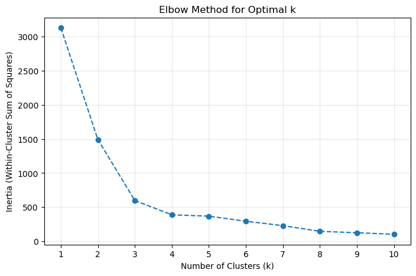

```python
"""1.2) Using only x and y (exclude “org_cluster” column), use the k-means algorithm to
cluster the dataset number of clusters from 1 to 10. If you are using sklearn, set a
fixed random state to 0. Plot inertia (within-cluster sum of squares) against the
number of clusters. What is the best number of clusters for this data and why? """

# Extracting x and y columns (excluding org_cluster)
x = df1[['x', 'y']].values

# Compute k-means clustering for k = 1 to 10 and store inertia values
inertia = []
for k in range(1, 11):
    kmeans = KMeans(n_clusters=k, random_state=0)
    kmeans.fit(x)
    inertia.append(kmeans.inertia_)

# Plot inertia vs. number of clusters
plt.figure(figsize=(8, 5))
plt.plot(range(1, 11), inertia, marker='o', linestyle='--')
plt.xlabel('Number of Clusters (k)')
plt.ylabel('Inertia (Within-Cluster Sum of Squares)')
plt.title('Elbow Method for Optimal k')
plt.xticks(range(1, 11))
plt.grid(alpha=0.3)
plt.show()
```

Inertia measures the within-cluster sum of squares. A lower inertia indicates that data points are closer to their cluster centres, suggesting better clustering. The optimal number of clusters is 3, based on the "Elbow Method". The elbow point is identified at k=3, where the rate of decrease in inertia slows significantly, indicating a balance between simplicity and representation of the dataset's structure.

Adding an extra cluster at k = 4 increases model complexity without providing a substantial improvement in within-cluster cohesion. Increasing the number of clusters makes the model harder to interpret. At k = 4, the clusters may start to capture more noise or minor patterns that don't significantly contribute to understanding the dataset. At k=3, adding more clusters yields diminishing returns in reducing inertia

```python
"""1.3) Use the k-means algorithm to cluster the dataset into 3 clusters. Then:
a) Calculate Rand index as an extrinsic measure (between the result of your
clustering, and the original cluster labels (org_cluster).

b) Calculate Silhouette Score as an intrinsic measure (unsupervised) (between
the result of your clustering and the data (x and y)). """

# Extract x and y coordinates
X = df1[['x', 'y']].values

# Original cluster labels
true_labels = df1['org_cluster']

# Perform k-means clustering with k=3
kmeans = KMeans(n_clusters=3, random_state=0)
predicted_labels = kmeans.fit_predict(X)

# a) Calculate Rand index (Adjusted Rand Index)
rand_index = adjusted_rand_score(true_labels, predicted_labels)

# b) Calculate Silhouette Score
silhouette_avg = silhouette_score(X, predicted_labels)

# Display results
rand_index, silhouette_avg
```

```
(0.7101262837417722, 0.609307520786181)
```

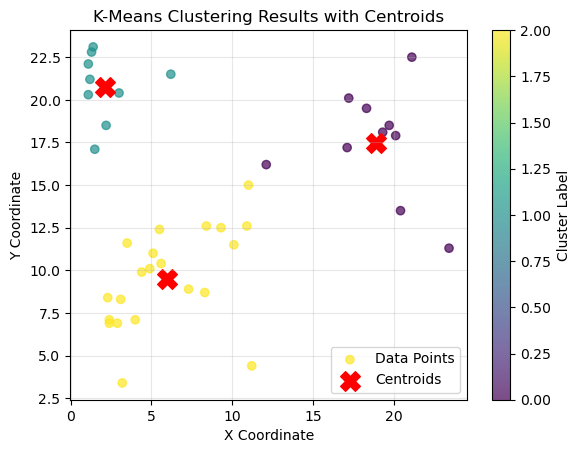

```python
"""1.4) Plots the clustering results, and highlight the centroids."""

# Scatter plot of the clustered points, colour-coded by predicted labels
scatter = plt.scatter(X[:, 0], X[:, 1], c=predicted_labels, cmap='viridis', alpha=0.7, label='Data Points')

# Highlight centroids
centroids = kmeans.cluster_centers_
plt.scatter(centroids[:, 0], centroids[:, 1], s=200, c='red', marker='X', label='Centroids')

# Adding labels and title
plt.colorbar(scatter, label='Cluster Label')
plt.xlabel('X Coordinate')
plt.ylabel('Y Coordinate')
plt.title('K-Means Clustering Results with Centroids')
plt.legend()
plt.grid(alpha=0.3)
plt.show()
```

Question 2: K-Means Clustering:

```python
""" Read the data file into a Pandas data frame. Inspect Data"""

cwd = os.getcwd()
print("Current Working Directory:", cwd)

df2 = pd.read_csv("question_2.csv")

df2.head(10)
```

```
Current Working Directory: c:\Users\35385\Desktop\CS_Autumn2024\DataMining\Tom_Gibson-p3
```

|  | NAME | MANUF | TYPE | CALORIES | PROTEIN | FAT | SODIUM | FIBER | CARBO | SUGARS | POTASS | VITAMINS | SHELF | WEIGHT | CUPS | RATING |
| --- | --- | --- | --- | --- | --- | --- | --- | --- | --- | --- | --- | --- | --- | --- | --- | --- |
| 0 | 100%_Bran | N | C | 70 | 4 | 1 | 130 | 10.0 | 5.0 | 6 | 280 | 25 | 3 | 1.00 | 0.33 | 68.402973 |
| 1 | 100%_Natural_Bran | Q | C | 120 | 3 | 5 | 15 | 2.0 | 8.0 | 8 | 135 | 0 | 3 | 1.00 | 1.00 | 33.983679 |
| 2 | All-Bran | K | C | 70 | 4 | 1 | 260 | 9.0 | 7.0 | 5 | 320 | 25 | 3 | 1.00 | 0.33 | 59.425505 |
| 3 | All-Bran_with_Extra_Fiber | K | C | 50 | 4 | 0 | 140 | 14.0 | 8.0 | 0 | 330 | 25 | 3 | 1.00 | 0.50 | 93.704912 |
| 4 | Almond_Delight | R | C | 110 | 2 | 2 | 200 | 1.0 | 14.0 | 8 | -1 | 25 | 3 | 1.00 | 0.75 | 34.384843 |
| 5 | Apple_Cinnamon_Cheerios | G | C | 110 | 2 | 2 | 180 | 1.5 | 10.5 | 10 | 70 | 25 | 1 | 1.00 | 0.75 | 29.509541 |
| 6 | Apple_Jacks | K | C | 110 | 2 | 0 | 125 | 1.0 | 11.0 | 14 | 30 | 25 | 2 | 1.00 | 1.00 | 33.174094 |
| 7 | Basic_4 | G | C | 130 | 3 | 2 | 210 | 2.0 | 18.0 | 8 | 100 | 25 | 3 | 1.33 | 0.75 | 37.038562 |
| 8 | Bran_Chex | R | C | 90 | 2 | 1 | 200 | 4.0 | 15.0 | 6 | 125 | 25 | 1 | 1.00 | 0.67 | 49.120253 |
| 9 | Bran_Flakes | P | C | 90 | 3 | 0 | 210 | 5.0 | 13.0 | 5 | 190 | 25 | 3 | 1.00 | 0.67 | 53.313813 |

```python
df2.info()
```

```
<class 'pandas.core.frame.DataFrame'>
RangeIndex: 77 entries, 0 to 76
Data columns (total 16 columns):
 #   Column    Non-Null Count  Dtype
---  ------    --------------  -----
 0   NAME      77 non-null     object
 1   MANUF     77 non-null     object
 2   TYPE      77 non-null     object
 3   CALORIES  77 non-null     int64
 4   PROTEIN   77 non-null     int64
 5   FAT       77 non-null     int64
 6   SODIUM    77 non-null     int64
 7   FIBER     77 non-null     float64
 8   CARBO     77 non-null     float64
 9   SUGARS    77 non-null     int64
 10  POTASS    77 non-null     int64
 11  VITAMINS  77 non-null     int64
 12  SHELF     77 non-null     int64
 13  WEIGHT    77 non-null     float64
 14  CUPS      77 non-null     float64
 15  RATING    77 non-null     float64
dtypes: float64(5), int64(8), object(3)
memory usage: 9.8+ KB
```

```python
"""2.1) Discard the columns NAME, MANUF, TYPE, and RATING."""

columns_to_discard = ['NAME', 'MANUF', 'TYPE', 'RATING']
df2 = df2.drop(columns=columns_to_discard, errors='ignore')
df2
```

|  | CALORIES | PROTEIN | FAT | SODIUM | FIBER | CARBO | SUGARS | POTASS | VITAMINS | SHELF | WEIGHT | CUPS |
| --- | --- | --- | --- | --- | --- | --- | --- | --- | --- | --- | --- | --- |
| 0 | 70 | 4 | 1 | 130 | 10.0 | 5.0 | 6 | 280 | 25 | 3 | 1.0 | 0.33 |
| 1 | 120 | 3 | 5 | 15 | 2.0 | 8.0 | 8 | 135 | 0 | 3 | 1.0 | 1.00 |
| 2 | 70 | 4 | 1 | 260 | 9.0 | 7.0 | 5 | 320 | 25 | 3 | 1.0 | 0.33 |
| 3 | 50 | 4 | 0 | 140 | 14.0 | 8.0 | 0 | 330 | 25 | 3 | 1.0 | 0.50 |
| 4 | 110 | 2 | 2 | 200 | 1.0 | 14.0 | 8 | -1 | 25 | 3 | 1.0 | 0.75 |
| ... | ... | ... | ... | ... | ... | ... | ... | ... | ... | ... | ... | ... |
| 72 | 110 | 2 | 1 | 250 | 0.0 | 21.0 | 3 | 60 | 25 | 3 | 1.0 | 0.75 |
| 73 | 110 | 1 | 1 | 140 | 0.0 | 13.0 | 12 | 25 | 25 | 2 | 1.0 | 1.00 |
| 74 | 100 | 3 | 1 | 230 | 3.0 | 17.0 | 3 | 115 | 25 | 1 | 1.0 | 0.67 |
| 75 | 100 | 3 | 1 | 200 | 3.0 | 17.0 | 3 | 110 | 25 | 1 | 1.0 | 1.00 |
| 76 | 110 | 2 | 1 | 200 | 1.0 | 16.0 | 8 | 60 | 25 | 1 | 1.0 | 0.75 |

77 rows × 12 columns

```python
"""2.2) Run the k-means algorithm using 5 clusters as a target, 5 maximum runs, and 100
maximum optimization steps. Keep the random state to 0. Save the cluster labels in a
new column called config1. """

# Define the KMeans algorithm with specified parameters
kmeans_config1 = KMeans(n_clusters=5, n_init=5, max_iter=100, random_state=0)

# Fit the model and predict cluster labels
df2['config1'] = kmeans_config1.fit_predict(df2)

df2
```

|  | CALORIES | PROTEIN | FAT | SODIUM | FIBER | CARBO | SUGARS | POTASS | VITAMINS | SHELF | WEIGHT | CUPS | config1 |
| --- | --- | --- | --- | --- | --- | --- | --- | --- | --- | --- | --- | --- | --- |
| 0 | 70 | 4 | 1 | 130 | 10.0 | 5.0 | 6 | 280 | 25 | 3 | 1.0 | 0.33 | 0 |
| 1 | 120 | 3 | 5 | 15 | 2.0 | 8.0 | 8 | 135 | 0 | 3 | 1.0 | 1.00 | 2 |
| 2 | 70 | 4 | 1 | 260 | 9.0 | 7.0 | 5 | 320 | 25 | 3 | 1.0 | 0.33 | 0 |
| 3 | 50 | 4 | 0 | 140 | 14.0 | 8.0 | 0 | 330 | 25 | 3 | 1.0 | 0.50 | 0 |
| 4 | 110 | 2 | 2 | 200 | 1.0 | 14.0 | 8 | -1 | 25 | 3 | 1.0 | 0.75 | 1 |
| ... | ... | ... | ... | ... | ... | ... | ... | ... | ... | ... | ... | ... | ... |
| 72 | 110 | 2 | 1 | 250 | 0.0 | 21.0 | 3 | 60 | 25 | 3 | 1.0 | 0.75 | 3 |
| 73 | 110 | 1 | 1 | 140 | 0.0 | 13.0 | 12 | 25 | 25 | 2 | 1.0 | 1.00 | 1 |
| 74 | 100 | 3 | 1 | 230 | 3.0 | 17.0 | 3 | 115 | 25 | 1 | 1.0 | 0.67 | 3 |
| 75 | 100 | 3 | 1 | 200 | 3.0 | 17.0 | 3 | 110 | 25 | 1 | 1.0 | 1.00 | 4 |
| 76 | 110 | 2 | 1 | 200 | 1.0 | 16.0 | 8 | 60 | 25 | 1 | 1.0 | 0.75 | 1 |

77 rows × 13 columns

```python
"""2.3) Run k-means again, using 5 clusters as a target, 100 maximum runs, and 100 maximum
optimization steps. Again, use a random state of 0. Save the cluster labels in a new
column called config2."""

kmeans_config2 = KMeans(n_clusters=5, n_init=100, max_iter=100, random_state=0)

# Fit the model and predict cluster labels
df2['config2'] = kmeans_config2.fit_predict(df2)

df2
```

|  | CALORIES | PROTEIN | FAT | SODIUM | FIBER | CARBO | SUGARS | POTASS | VITAMINS | SHELF | WEIGHT | CUPS | config1 | config2 |
| --- | --- | --- | --- | --- | --- | --- | --- | --- | --- | --- | --- | --- | --- | --- |
| 0 | 70 | 4 | 1 | 130 | 10.0 | 5.0 | 6 | 280 | 25 | 3 | 1.0 | 0.33 | 0 | 4 |
| 1 | 120 | 3 | 5 | 15 | 2.0 | 8.0 | 8 | 135 | 0 | 3 | 1.0 | 1.00 | 2 | 2 |
| 2 | 70 | 4 | 1 | 260 | 9.0 | 7.0 | 5 | 320 | 25 | 3 | 1.0 | 0.33 | 0 | 4 |
| 3 | 50 | 4 | 0 | 140 | 14.0 | 8.0 | 0 | 330 | 25 | 3 | 1.0 | 0.50 | 0 | 4 |
| 4 | 110 | 2 | 2 | 200 | 1.0 | 14.0 | 8 | -1 | 25 | 3 | 1.0 | 0.75 | 1 | 0 |
| ... | ... | ... | ... | ... | ... | ... | ... | ... | ... | ... | ... | ... | ... | ... |
| 72 | 110 | 2 | 1 | 250 | 0.0 | 21.0 | 3 | 60 | 25 | 3 | 1.0 | 0.75 | 3 | 0 |
| 73 | 110 | 1 | 1 | 140 | 0.0 | 13.0 | 12 | 25 | 25 | 2 | 1.0 | 1.00 | 1 | 3 |
| 74 | 100 | 3 | 1 | 230 | 3.0 | 17.0 | 3 | 115 | 25 | 1 | 1.0 | 0.67 | 3 | 1 |
| 75 | 100 | 3 | 1 | 200 | 3.0 | 17.0 | 3 | 110 | 25 | 1 | 1.0 | 1.00 | 4 | 1 |
| 76 | 110 | 2 | 1 | 200 | 1.0 | 16.0 | 8 | 60 | 25 | 1 | 1.0 | 0.75 | 1 | 0 |

77 rows × 14 columns

```python
"""2.3) Run the clustering algorithm again, using only 3 clusters, 100 maximum runs, and 100
maximum optimization steps. Save the generated cluster labels in a new column called
config3."""

kmeans_config3 = KMeans(n_clusters=3, n_init=100, max_iter=100, random_state=0)

# Fit the model and predict cluster labels
df2['config3'] = kmeans_config3.fit_predict(df2)

df2
```

|  | CALORIES | PROTEIN | FAT | SODIUM | FIBER | CARBO | SUGARS | POTASS | VITAMINS | SHELF | WEIGHT | CUPS | config1 | config2 | config3 |
| --- | --- | --- | --- | --- | --- | --- | --- | --- | --- | --- | --- | --- | --- | --- | --- |
| 0 | 70 | 4 | 1 | 130 | 10.0 | 5.0 | 6 | 280 | 25 | 3 | 1.0 | 0.33 | 0 | 4 | 2 |
| 1 | 120 | 3 | 5 | 15 | 2.0 | 8.0 | 8 | 135 | 0 | 3 | 1.0 | 1.00 | 2 | 2 | 1 |
| 2 | 70 | 4 | 1 | 260 | 9.0 | 7.0 | 5 | 320 | 25 | 3 | 1.0 | 0.33 | 0 | 4 | 2 |
| 3 | 50 | 4 | 0 | 140 | 14.0 | 8.0 | 0 | 330 | 25 | 3 | 1.0 | 0.50 | 0 | 4 | 2 |
| 4 | 110 | 2 | 2 | 200 | 1.0 | 14.0 | 8 | -1 | 25 | 3 | 1.0 | 0.75 | 1 | 0 | 0 |
| ... | ... | ... | ... | ... | ... | ... | ... | ... | ... | ... | ... | ... | ... | ... | ... |
| 72 | 110 | 2 | 1 | 250 | 0.0 | 21.0 | 3 | 60 | 25 | 3 | 1.0 | 0.75 | 3 | 0 | 0 |
| 73 | 110 | 1 | 1 | 140 | 0.0 | 13.0 | 12 | 25 | 25 | 2 | 1.0 | 1.00 | 1 | 3 | 0 |
| 74 | 100 | 3 | 1 | 230 | 3.0 | 17.0 | 3 | 115 | 25 | 1 | 1.0 | 0.67 | 3 | 1 | 0 |
| 75 | 100 | 3 | 1 | 200 | 3.0 | 17.0 | 3 | 110 | 25 | 1 | 1.0 | 1.00 | 4 | 1 | 0 |
| 76 | 110 | 2 | 1 | 200 | 1.0 | 16.0 | 8 | 60 | 25 | 1 | 1.0 | 0.75 | 1 | 0 | 0 |

77 rows × 15 columns

Each row represents a data point, and the column values of config denote the cluster assignment for that data point in each configuration.

```python
# Extract clustering results for each configuration
config1_labels = df2['config1']
config2_labels = df2['config2']
config3_labels = df2['config3']

# Calculate metrics
inertia = {
    "config1": kmeans_config1.inertia_,
    "config2": kmeans_config2.inertia_,
    "config3": kmeans_config3.inertia_
}

silhouette = {
    "config1": silhouette_score(df2, config1_labels),
    "config2": silhouette_score(df2, config2_labels),
    "config3": silhouette_score(df2, config3_labels)
}


inertia, silhouette
```

```
({'config1': 221733.43747009189,
  'config2': 221238.13677894333,
  'config3': 349869.71077997726},
 {'config1': 0.33562968078757743,
  'config2': 0.3602085473655013,
  'config3': 0.464288558305485})
```

Inertia represents the sum of squared distances between data points and their assigned cluster centres. Config3 performs the worst in terms of inertia, indicating less compact clusters. Config2 has the lowest inertia, slightly better than Config1, implying tighter clusters.

Silhouette scores range from -1 to 1. Higher scores indicate better-defined clusters. Config3 has the best silhouette score, meaning the clusters are better separated. However, the differences between Config2 and Config1 are marginal, while Config3 significantly outperforms.

As to which is "better", it depends on contextual goals. If cluster compactness is critical, Config2 is preferable because it has the lowest inertia, meaning clusters are tighter. If cluster separation is prioritised, Config3 is the best because of its significantly higher silhouette score. However, the trade-off is less compact clusters and deviation from Config1's structure.

If one config had to be chosen however, Config2 offers a balanced solution with good compactness (lowest inertia), and reasonable separation (second-best silhouette score).

Question 3: DBSCAN Clustering Algorithm

```python
""" Read the data file into a Pandas data frame. Inspect Data"""

cwd = os.getcwd()
print("Current Working Directory:", cwd)

df3 = pd.read_csv("question_3.csv")

df3.head(10)
```

```
Current Working Directory: c:\Users\35385\Desktop\CS_Autumn2024\DataMining\Tom_Gibson-p3
```

|  | ID | x | y |
| --- | --- | --- | --- |
| 0 | 1150 | -8.667331 | 41.149643 |
| 1 | 1151 | -8.666030 | 41.153057 |
| 2 | 1152 | -8.669282 | 41.152732 |
| 3 | 1153 | -8.664242 | 41.150455 |
| 4 | 1154 | -8.663267 | 41.152894 |
| 5 | 1155 | -8.661641 | 41.150618 |
| 6 | 1156 | -8.663104 | 41.148505 |
| 7 | 1157 | -8.665705 | 41.147854 |
| 8 | 1158 | -8.668469 | 41.154520 |
| 9 | 1159 | -8.666193 | 41.155008 |

```python
df3.info()
```

```
<class 'pandas.core.frame.DataFrame'>
RangeIndex: 322 entries, 0 to 321
Data columns (total 3 columns):
 #   Column  Non-Null Count  Dtype
---  ------  --------------  -----
 0   ID      322 non-null    int64
 1   x       322 non-null    float64
 2   y       322 non-null    float64
dtypes: float64(2), int64(1)
memory usage: 7.7 KB
```

```python
"""3.1) Discard the ID column, then use the X and Y coordinates as data input to the K-Means
algorithm to cluster it into 7 clusters. Perform 5 maximum runs and 100 maximum
optimization steps. Keep a random state to 0. Save the cluster labels into a new column
called k-means. """

df3 = df3.drop(columns=['ID'])

# Extract the X and Y coordinates for clustering
coordinates = df3[['x', 'y']]

# Apply K-Means clustering
kmeans = KMeans(n_clusters=7, max_iter=100, n_init=5, random_state=0)
df3['k-means'] = kmeans.fit_predict(coordinates)

df3
```

|  | x | y | k-means |
| --- | --- | --- | --- |
| 0 | -8.667331 | 41.149643 | 2 |
| 1 | -8.666030 | 41.153057 | 2 |
| 2 | -8.669282 | 41.152732 | 2 |
| 3 | -8.664242 | 41.150455 | 2 |
| 4 | -8.663267 | 41.152894 | 2 |
| ... | ... | ... | ... |
| 317 | -8.688467 | 41.151431 | 5 |
| 318 | -8.679037 | 41.156146 | 5 |
| 319 | -8.606201 | 41.139888 | 6 |
| 320 | -8.574660 | 41.145253 | 6 |
| 321 | -8.613354 | 41.172079 | 1 |

322 rows × 3 columns

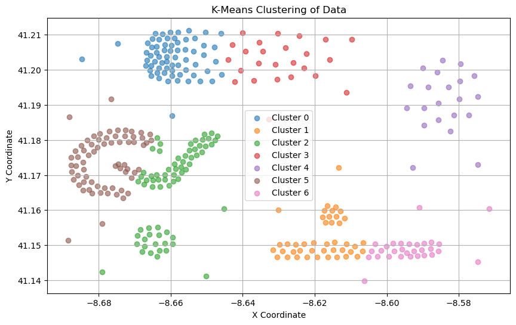

```python
"""3.2) Plot the generated clusters. Do you think this clustering is suitable and why?"""

plt.figure(figsize=(10, 6))
for cluster in range(7):
    cluster_data = df3[df3['k-means'] == cluster]
    plt.scatter(cluster_data['x'], cluster_data['y'], label=f'Cluster {cluster}', alpha=0.6)

plt.title('K-Means Clustering of Data')
plt.xlabel('X Coordinate')
plt.ylabel('Y Coordinate')
plt.legend()
plt.grid(True)
plt.show()
```

The generated plot displays the clusters formed by the K-Means algorithm.

If the clusters are well-separated, with minimal overlap between them, the clustering is likely suitable. Compactness: Each cluster should ideally form a tight group, without excessive scatter. Domain Context: Suitability also depends on the purpose of clustering and the domain context. For example, if the clusters align with expected geographical or categorical groupings, the result is more meaningful.

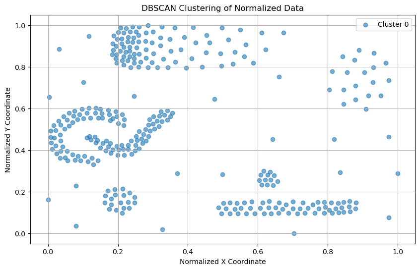

```python
"""3.3) Normalize the X and Y columns in a range between 0 and 1, then use the DBSCAN
algorithm to cluster the points again. Use a value of 0.4 for epsilon, and set the
minimum points equal to 4, and set the metric to ‘Euclidean’. Plot the result, and save
the cluster labels into a new column called dbscan1."""

# Normalize the X and Y columns
scaler = MinMaxScaler()
df3[['x', 'y']] = scaler.fit_transform(df3[['x', 'y']])

# Apply DBSCAN clustering
dbscan = DBSCAN(eps=0.4, min_samples=4, metric='euclidean')
df3['dbscan1'] = dbscan.fit_predict(df3[['x', 'y']])

# Plot the DBSCAN clustering results
plt.figure(figsize=(10, 6))
unique_labels = df3['dbscan1'].unique()

for label in unique_labels:
    cluster_data = df3[df3['dbscan1'] == label]
    plt.scatter(cluster_data['x'], cluster_data['y'], label=f'Cluster {label}' if label != -1 else 'Noise', alpha=0.6)

plt.title('DBSCAN Clustering of Normalized Data')
plt.xlabel('Normalized X Coordinate')
plt.ylabel('Normalized Y Coordinate')
plt.legend()
plt.grid(True)
plt.show()
```

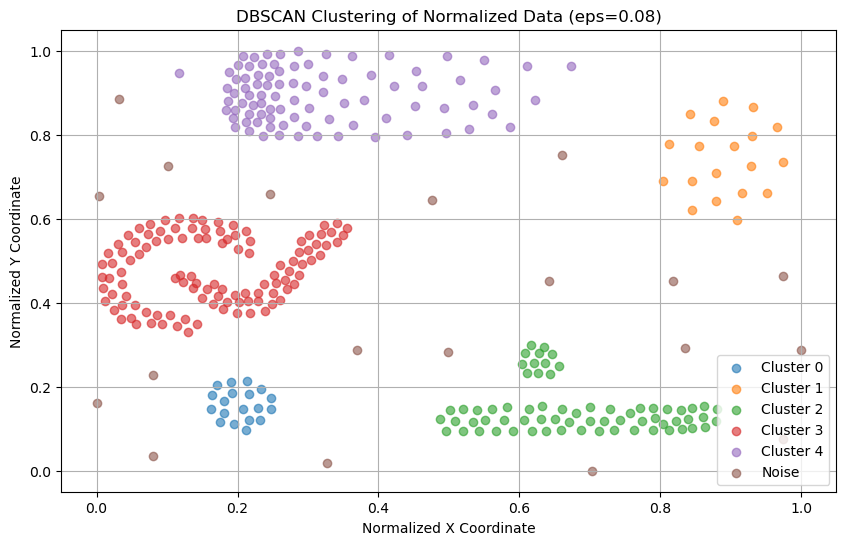

```python
"""3.4) Execute DBSCAN again, but this time use a value of 0.08 for epsilon. Plot the result, and
save the cluster labels into a new column called dbscan2 """

dbscan2 = DBSCAN(eps=0.08, min_samples=4, metric='euclidean')
df3['dbscan2'] = dbscan2.fit_predict(df3[['x', 'y']])

# Plot the DBSCAN clustering results with the new epsilon
plt.figure(figsize=(10, 6))
unique_labels = df3['dbscan2'].unique()

for label in unique_labels:
    cluster_data = df3[df3['dbscan2'] == label]
    plt.scatter(cluster_data['x'], cluster_data['y'], label=f'Cluster {label}' if label != -1 else 'Noise', alpha=0.6)

plt.title('DBSCAN Clustering of Normalized Data (eps=0.08)')
plt.xlabel('Normalized X Coordinate')
plt.ylabel('Normalized Y Coordinate')
plt.legend()
plt.grid(True)
plt.show()
```

"""3.5) Compare the three clustering results (k-means, dbscan1 and dbscan2). Which solution is the best? And why? """

Best Solution DBSCAN with eps=0.08 (dbscan2) appears to be the most suitable for this dataset. It captures the non-linear, arbitrary-shaped clusters effectively and includes a clear noise classification. Compared to K-Means, it adapts better to the data's shape and distribution. Compared to DBSCAN with eps=0.4, it avoids merging distinct clusters and provides a more meaningful separation.